# ECON6027_2b

Dr. Liu

# Coordinate reference systems and projections

We can use the following commands to inspect the CRS object (if it exists) in the loaded dataset.

```r
library(sf); library(spData)
# CRS
st_crs(world)
```

```
## Coordinate Reference System:
##   User input: EPSG:4326
##   wkt:
## GEOGCRS["WGS 84",
##     DATUM["World Geodetic System 1984",
##         ELLIPSOID["WGS 84",6378137,298.257223563,
##             LENGTHUNIT["metre",1]]],
##     PRIMEM["Greenwich",0,
##         ANGLEUNIT["degree",0.0174532925199433]],
##     CS[ellipsoidal,2],
##         AXIS["geodetic latitude (Lat)",north,
##             ORDER[1],
##             ANGLEUNIT["degree",0.0174532925199433]],
##         AXIS["geodetic longitude (Lon)",east,
##             ORDER[2],
##             ANGLEUNIT["degree",0.0174532925199433]],
##     USAGE[
##         SCOPE["Horizontal component of 3D system."],
##         AREA["World."],
##         BBOX[-90,-180,90,180]],
##     ID["EPSG",4326]]
```

```r
# st_crs(world)$wkt
st_crs(world)$epsg
```

```
## [1] 4326
```

```r
st_crs(world)$Name
```

```
## [1] "WGS 84"
```

```r
st_crs(world)$proj4string
```

```
## [1] "+proj=longlat +datum=WGS84 +no_defs"
```

```r
st_crs(seine)$proj4string
```

```
## [1] "+proj=lcc +lat_0=46.5 +lon_0=3 +lat_1=49 +lat_2=44 +x_0=700000 +y_0=6600000 +ellps=GRS80 +towgs84=0,0,0,0,0,0,0 +units=m +no_defs"
```

```r
sf_proj_info(type = "ellps") # available ellipsoids
```

```
##         name          major                  ell
## 1      MERIT    a=6378137.0           rf=298.257
## 2      SGS85    a=6378136.0           rf=298.257
## 3      GRS80    a=6378137.0     rf=298.257222101
## 4      IAU76    a=6378140.0           rf=298.257
## 5       airy  a=6377563.396       rf=299.3249646
## 6     APL4.9    a=6378137.0            rf=298.25
## 7      NWL9D    a=6378145.0            rf=298.25
## 8   mod_airy  a=6377340.189        b=6356034.446
## 9     andrae   a=6377104.43             rf=300.0
## 10    danish a=6377019.2563             rf=300.0
## 11   aust_SA    a=6378160.0            rf=298.25
## 12     GRS67    a=6378160.0    rf=298.2471674270
## 13   GSK2011    a=6378136.5       rf=298.2564151
## 14    bessel  a=6377397.155       rf=299.1528128
```

[output cut: 79 more lines]

```r
# rf = a/(a-b), the inverse flattening parameter
sf_proj_info(type = "proj") # available projections
```

```
##             name
## 1     adams_hemi
## 2      adams_ws1
## 3      adams_ws2
## 4            aea
## 5           aeqd
## 6         affine
## 7           airy
## 8         aitoff
## 9           alsk
## 10         apian
## 11        august
## 12      axisswap
## 13         bacon
## 14    bertin1953
```

[output cut: 347 more lines]

## GET TO WORK: Fiji dataset

The data set give the locations of 1000 seismic events of MB > 4.0. The events occurred in a cube near Fiji since 1964. This is a basic data frame that treats the positional data in “lat” and “lon” as another set of attributes.

```r
fiji = datasets::quakes
head(fiji)
```

```
##      lat   long depth mag stations
## 1 -20.42 181.62   562 4.8       41
## 2 -20.62 181.03   650 4.2       15
## 3 -26.00 184.10    42 5.4       43
## 4 -17.97 181.66   626 4.1       19
## 5 -20.42 181.96   649 4.0       11
## 6 -19.68 184.31   195 4.0       12
```

```r
class(fiji)
```

```
## [1] "data.frame"
```

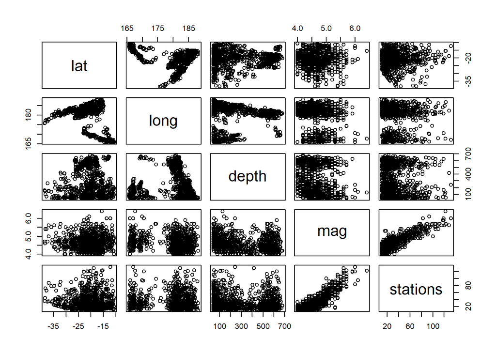

```r
plot(fiji)
```

Let us give this dataset “spatial awareness”

```r
fiji.sf = st_as_sf(fiji, coords=c("long","lat"))
class(fiji.sf)
```

```
## [1] "sf"         "data.frame"
```

```r
summary(fiji.sf)
```

```
##      depth            mag          stations         geometry
##  Min.   : 40.0   Min.   :4.00   Min.   : 10.00   POINT  :1000
##  1st Qu.: 99.0   1st Qu.:4.30   1st Qu.: 18.00   epsg:NA:   0
##  Median :247.0   Median :4.60   Median : 27.00
##  Mean   :311.4   Mean   :4.62   Mean   : 33.42
##  3rd Qu.:543.0   3rd Qu.:4.90   3rd Qu.: 42.00
##  Max.   :680.0   Max.   :6.40   Max.   :132.00
```

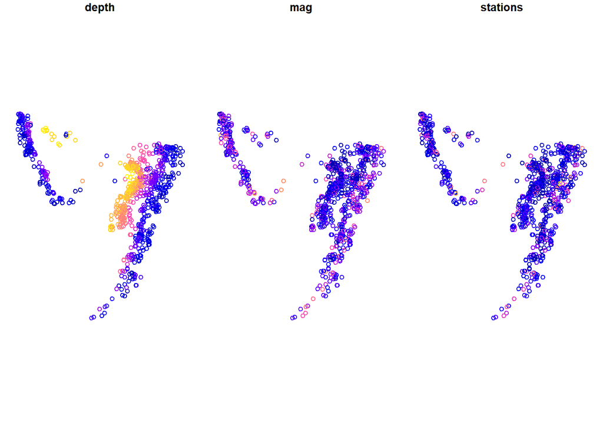

```r
plot(fiji.sf)
```

We have an sf object that is aware of location… However, no CRS.

```r
st_is_longlat(fiji.sf)
```

```
## [1] NA
```

```r
st_crs(fiji.sf)
```

```
## Coordinate Reference System: NA
```

That means we know the numbers refer to “locations”, but we have no idea where on “Earth” exactly these locations are. In general, geographic datasets without a CRS can be of limited use unless we are conducting an isolated study of some sort.

It is ok not to know a CRS too. Only earth locations can have a CRS, but spatial data analysis is much larger. A “space” can be defined in many non-geographic forms including social networks, parts of your body, areas of a building, etc that. Even geographic locations that we study may not conform to the standard Earth CRS definitions (like sunspots or lunar craters).

Due to this reason if no CRS is specified, sf is still able to perform all the calculations.

### Geographic CRS

The dataset gives latitudes and longitudes near Fiji, we know they come from EPSG4326. EPSG:4326 -WGS 84, is latitude/longitude coordinate system based on the Earth’s centre of mass, used by the GPS system among others.

```r
fiji.geo = st_set_crs(fiji.sf, 4326)
st_is_longlat(fiji.geo)
```

```
## [1] TRUE
```

```r
st_crs(fiji.geo)$proj4string
```

```
## [1] "+proj=longlat +datum=WGS84 +no_defs"
```

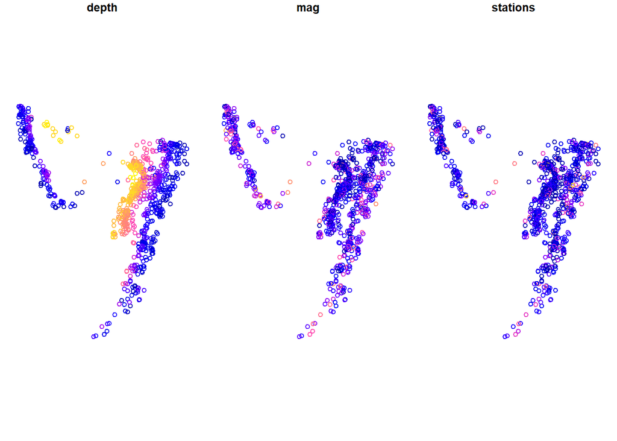

```r
plot(fiji.geo)
```

### Projected CRS

We project/re-project spatial objects when (i) we perform **metric** distance-based analyses, (ii) we want to compare more than one dataset with different CRS definitions, and (iii) online publishing of data may require certain conventions. Some examples are given below.

Robinson projection:

```r
fiji.proj = st_transform(fiji.geo, crs = "+proj=robin")
st_crs(fiji.proj)$proj4string
```

```
## [1] "+proj=robin +lon_0=0 +x_0=0 +y_0=0 +datum=WGS84 +units=m +no_defs"
```

```r
st_crs(fiji.proj)$epsg
```

```
## [1] NA
```

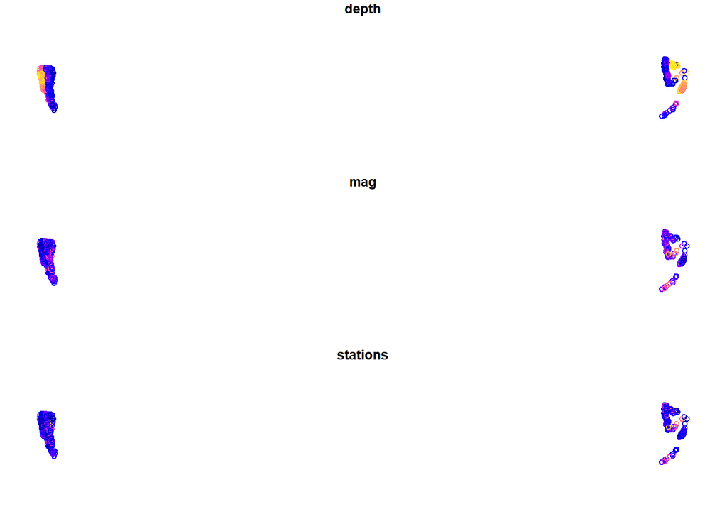

```r
plot(fiji.proj) # clearly this projection is not suitable for the data.
```

Pseudo Mercator projection:

```r
fiji.proj2 = st_transform(fiji.geo, crs=3857)
st_crs(fiji.proj2)$proj4string
```

```
## [1] "+proj=merc +a=6378137 +b=6378137 +lat_ts=0 +lon_0=0 +x_0=0 +y_0=0 +k=1 +units=m +nadgrids=@null +wktext +no_defs"
```

```r
st_crs(fiji.proj2)$epsg
```

```
## [1] 3857
```

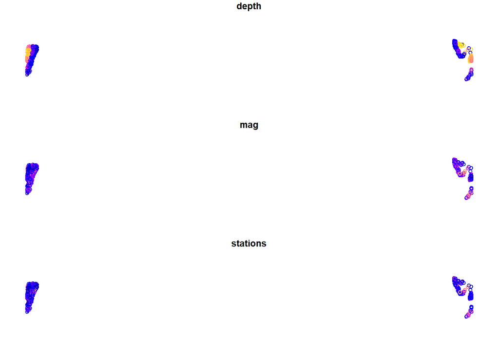

```r
plot(fiji.proj2) # not good again
```

### UTM

A commonly used default is Universal Transverse Mercator (UTM): A set of CRSs that divides the Earth into 60 longitudinal wedges and 20 latitudinal segments. The UTM projection is commonly used in research because it tends to be more locally accurate, and furthermore, it has attributes that make the estimating distance easy and accurate. Positions are described using Easting and Northing coordinates.

Almost every place on Earth has a UTM code. All UTM projections have the same datum (WGS84) and their EPSG codes run sequentially from 32601 to 32660 for northern hemisphere locations and from 32701 to 32760 for southern hemisphere locations.

```r
source("LonLat2UTM.R") # Load function
sg.coords = c(103.82,1.35)
(utm.sg = lonlat2UTM(sg.coords))
```

```
## [1] 32648
```

```r
#st_crs(utm.sg)
st_crs(utm.sg)$proj4string
```

```
## [1] "+proj=utm +zone=48 +datum=WGS84 +units=m +no_defs"
```

Let us re-visit the Fiji dataset…

```r
fiji.coords = c(178.07, -17.71) # confirm this
(utm.fiji = lonlat2UTM(fiji.coords))
```

```
## [1] 32760
```

```r
st_crs(utm.fiji)$proj4string
```

```
## [1] "+proj=utm +zone=60 +south +datum=WGS84 +units=m +no_defs"
```

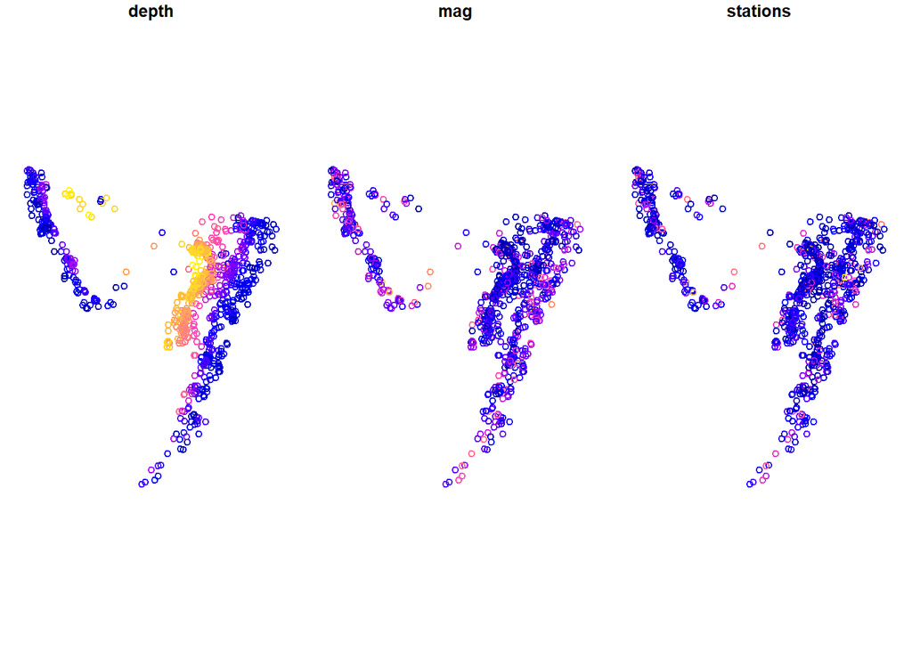

```r
fiji.proj3 = st_transform(fiji.geo, crs=utm.fiji)
plot(fiji.proj3) # much better!
```